# Lab 5

Lucas Street, 1874989

```python
%%capture
import sys
!{sys.executable} -m pip install --user scipy numpy matplotlib pandas pyuvdata
# Also install https://github.com/HERA-Team/hera_cal

%matplotlib inline
import matplotlib
import matplotlib.pyplot as plt
matplotlib.rc('font', size=22)
matplotlib.rc('figure', figsize=(18, 10))

import numpy as np
import scipy as sp
import pandas as pd
from scipy import stats
from hera_cal.io import HERAData
```

The Hydrogen Epoch of Reionization Array (HERA) is an array of radio telescopes located in [South Africa](https://goo.gl/maps/44ntQEovA51L792m6), built to search for signals from the red-shifted 21 cm hydrogen line. It is currently composed of 52 dishes, each 14 meters wide, packed in a hexagonal grid. The antenna in each dish measures an electromagnetic field over a certain amount of time, and since waves from distant sources are usually plane waves incident upon the telescope array at some angle, the signal reaches some telescopes before others. To reap the benefits of radio interferometry, the signals from any two telescopes are time-delayed such that they lie in the same time interval, then the data is correlated, Fourier-transformed, and averaged to view the frequency spectrum observed in that time interval. The pair of dishes composes a *baseline*, which is the displacement vector between the two dishes.

In this data set, there are 52 active dishes, 1,378 baselines available to examine, and 60 time intervals for each baseline, with the data for each baseline-time having 1024 amplitudes for frequencies between 100 MHz and 200 MHz. There are also 4 polarizations of light to choose from: XX, XY, YX, and YY.

From [this internal HERA memo](http://reionization.org/manual_uploads/HERA069_IDR2.2_Memo_v2.html), the units for each time interval value is given in Julian day numbers, the frequencies are given in Hertz, and the amplitude for each frequency is a complex value called the *interferometric visibility*.

```python
filename = 'zen.2458108.57290.HH.uvh5'
hd = HERAData(filename)
print('antenna numbers:', sorted(hd.antenna_numbers))
print('antenna pairs:', len(hd.get_antpairs()))
```

```
antenna numbers: [0, 1, 2, 11, 12, 13, 14, 23, 24, 25, 26, 27, 36, 37, 38, 39, 40, 41, 50, 51, 52, 53, 54, 55, 65, 66, 67, 68, 69, 70, 71, 82, 83, 84, 85, 86, 87, 88, 98, 120, 121, 122, 123, 124, 136, 137, 138, 139, 140, 141, 142, 143]
antenna pairs: 1378
```

Next, I will define a few functions that will help us visualize the frequency spectra from these telescopes.

```python
def get_spectrogram(hd, selected_times, freq_channels, *args, filter_dupes=False, **kwargs):
    hd.read(times=selected_times, freq_chans=freq_channels)
    if filter_dupes:
        pairs = np.array(hd.get_antpairs())
        no_dupe_pairs = pairs[pairs[:, 0] != pairs[:, 1]]
        hd.select(bls=list(map(tuple, no_dupe_pairs)))
    data = hd.get_data(*args, **kwargs)
    times = hd.get_times(*args, **kwargs)
    times -= times[0]
    freqs_mhz = hd.freq_array.flatten() / 1e6
    return pd.DataFrame(data, times, freqs_mhz), times, freqs_mhz

def plot_spectrogram(freqs, times, data, colorbar=True):
    # Handle case where we only have one unique time
    single_time = False
    if times[0] == times[-1]:
        single_time = True
        times = [0, 1]

    plt.imshow(np.abs(data), origin='bottom', extent=(freqs[0], freqs[-1], times[0], times[-1]), aspect='auto')

    if single_time:
        # No need for a time axis if we only have one time
        plt.gca().get_yaxis().set_visible(False)

    plt.ylabel('Time (JD)')
    plt.xlabel('Frequency (MHz)')
    if colorbar:
        cbar = plt.colorbar()
        cbar.set_label('Amplitude')

def plot_avg_amplitudes(freqs, times, data):
    avg_amplitudes = np.mean(np.abs(data), axis=0)
    plt.plot(freqs, avg_amplitudes)
    plt.xlabel('Frequency (MHz)')
    plt.ylabel('Amplitude')
    plt.xlim(freqs[0], freqs[-1])
```

Now we can view any frequency spectrum for any baseline, over any amount of time. Let's examine the frequency spectrum of XX-polarized light for the baseline composed of telescopes 0 and 1 for the first 10 time intervals:

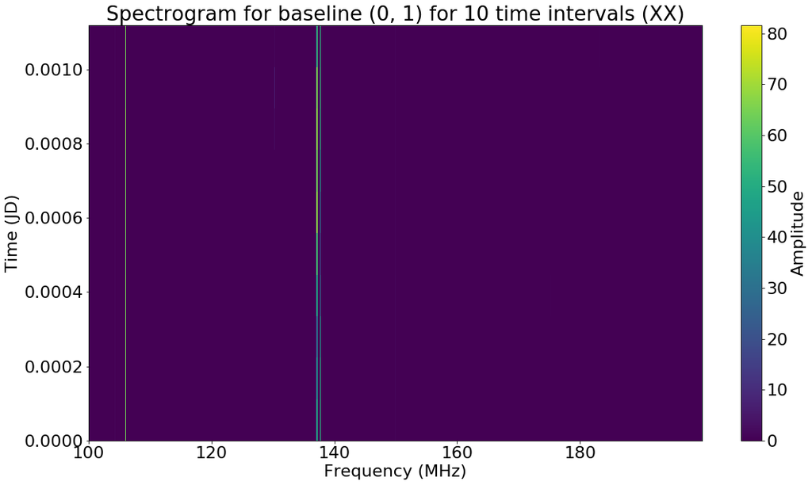

```python
data, times, freqs_mhz = get_spectrogram(hd, hd.times[0:10], np.arange(0, 1024), 0, 1, 'XX')
plt.title('Spectrogram for baseline (0, 1) for 10 time intervals (XX)')
plot_spectrogram(freqs_mhz, times, data, colorbar=True)
```

The time axis starts at 0, which is taken to be the time at which the entire dataset begins. This data is interesting, but it's hard to be sure what exactly it tells us about what the array sees as a whole.

Instead, let's stack the spectra of XX-polarized light for all 1,378 baselines in the first time interval on top of each other. Note that this is *not* a spectrogram, just a big stack of individual spectra.

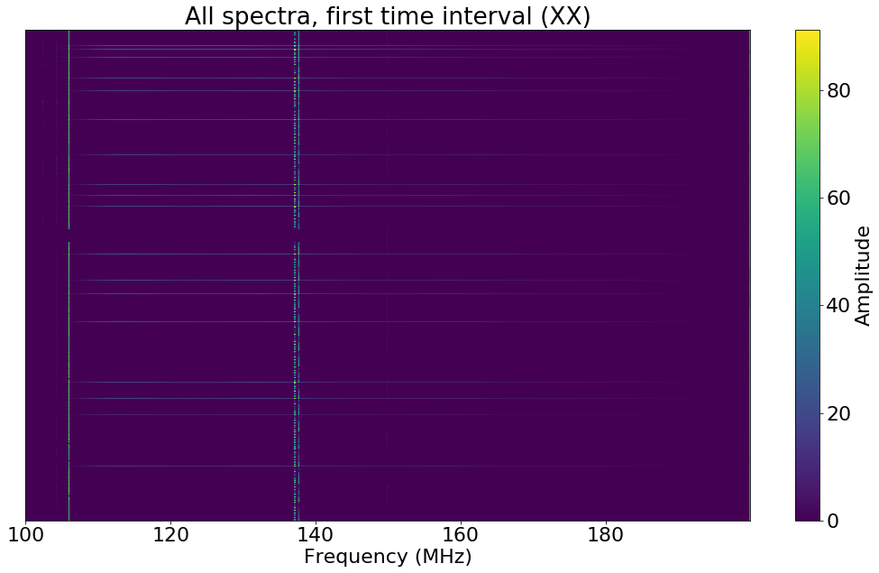

```python
data, times, freqs_mhz = get_spectrogram(hd, hd.times[0:1], np.arange(0, 1024), 'XX')
plt.title('All spectra, first time interval (XX)')
plot_spectrogram(freqs_mhz, times, data, colorbar=True)
```

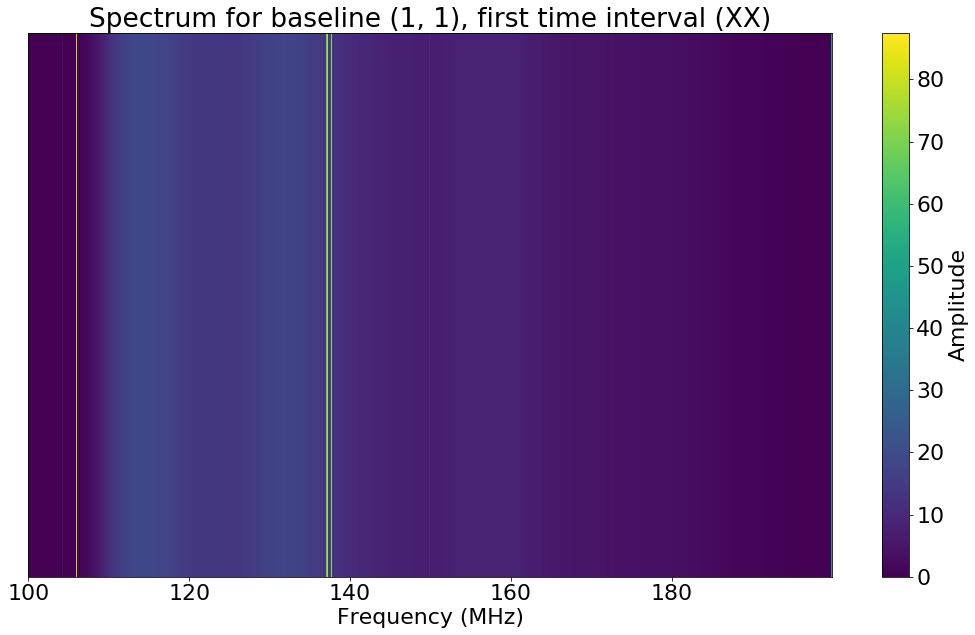

```python
data, times, freqs_mhz = get_spectrogram(hd, hd.times[0:1], np.arange(0, 1024), 1, 1, 'XX')
plt.title('Spectrum for baseline (1, 1), first time interval (XX)')
plot_spectrogram(freqs_mhz, times, data, colorbar=True)
```

Notice that this spectrum comes from a baseline composed of a telescope and itself (a baseline of zero), so it fails to gain any benefit of using a radio interferometer. The result is that external interference is correlated together and effectively amplified in the resulting spectrum. We do not want this data, so we'll filter out all baselines composed of only one telescope.

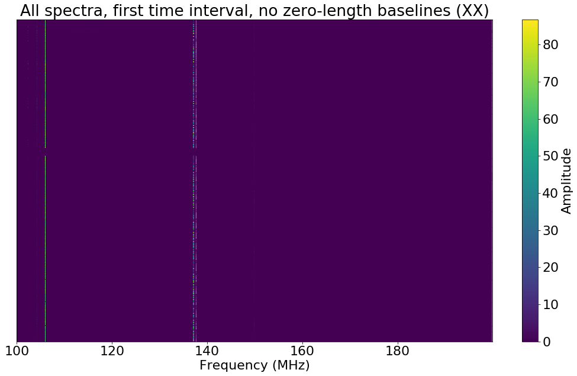

```python
data, times, freqs_mhz = get_spectrogram(hd, hd.times[0:1], np.arange(0, 1024), 'XX', filter_dupes=True)
plt.title('All spectra, first time interval, no zero-length baselines (XX)')
plot_spectrogram(freqs_mhz, times, data, colorbar=True)
```

Much better. Now we've selected baselines that give us 'clean'-looking data. If we average together every spectrum shown above, we get the average amplitudes versus frequency, which allows us to get an idea of what the entire array sees during one time interval.

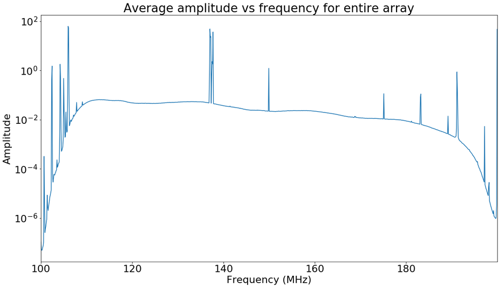

```python
plot_avg_amplitudes(freqs_mhz, times, data)
plt.title('Average amplitude vs frequency for entire array')
plt.yscale('log')
```

```python
def plot_histogram(times, frequency_channels, max_amplitude=0.4, polarization='XX'):
    all_antenna_data, _, _ = get_spectrogram(hd, times, frequency_channels, polarization)
    hist_data = np.abs(np.array(all_antenna_data).flatten())
    hist_data = hist_data[np.abs(hist_data) < max_amplitude]
    # print(len(hist_data))
    plt.title(f"Background distribution for time {times.round(4)}")
    plt.xlabel('Amplitude')
    plt.ylabel('Probability Density')
    plt.hist(hist_data, bins=100, density=True);
    return hist_data

def plot_lognormal_fit(hist_data, max_amplitude=0.4):
    sigma, mean, scale = stats.lognorm.fit(hist_data)
    dist = stats.lognorm(sigma, mean, scale)
    x = np.linspace(0, max_amplitude, 1000)
    y = dist.pdf(x)
    plt.plot(x, y, linewidth=4, alpha=0.8)
    plt.yscale('log')
    plt.xlim(0, max_amplitude)
    plt.ylim(1e-4)
    plt.legend(['Lognormal fit', 'Background'])
    print(f"Lognormal: mu: {mean}, sigma: {sigma}, s: {scale}")
    return sigma, mean, scale
```

```
Lognormal: mu: -0.0025773701652760756, sigma: 0.8931867040609118, s: 0.02510290734057528
```

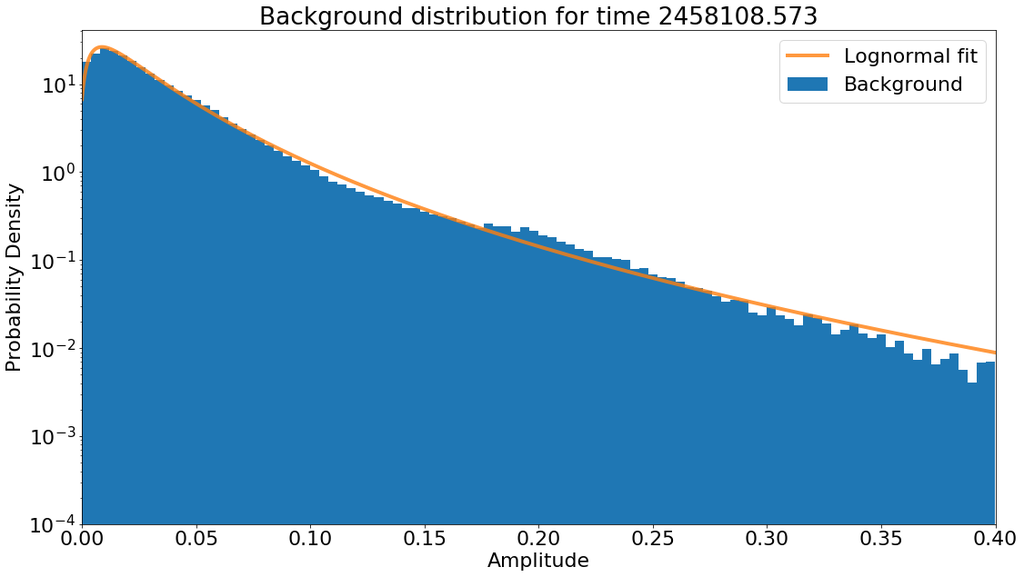

```python
hist_data = plot_histogram(hd.times[0], np.arange(100, 800))
sigma, mean, scale = plot_lognormal_fit(hist_data)
```

After considering several types of distributions, I found that a lognormal distribution seems to fit this background data fairly well. For parameters $\mu, \sigma, s$ printed above the plot, the lognormal PDF is given by $P(x|\mu, \sigma, s) = \frac{1}{\sigma x s \sqrt{2\pi}} \exp\left({-\frac{\log^2\left({\frac{x - \mu}{s}}\right)}{2\sigma^2}}\right)$

Let's make histograms of the same style above for several different time intervals, to see if the background distribution changes over time.

```
Lognormal: mu: -0.00248351679043981, sigma: 0.9009311840962354, s: 0.024868475857530804
```

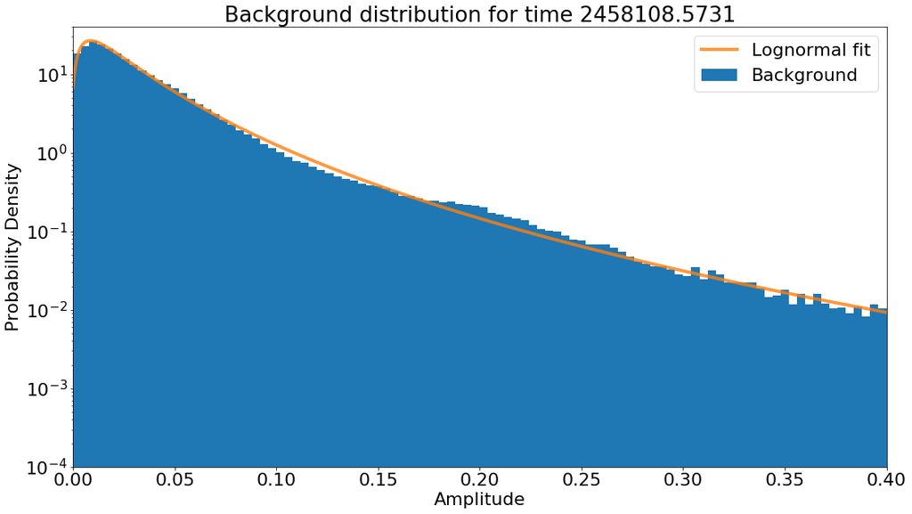

```python
hist_data_1 = plot_histogram(hd.times[1], np.arange(100, 800))
sigma_1, mean_1, scale_1 = plot_lognormal_fit(hist_data_1)
```

```
Lognormal: mu: -0.002460459713402246, sigma: 0.902143246211843, s: 0.024824077153268342
```

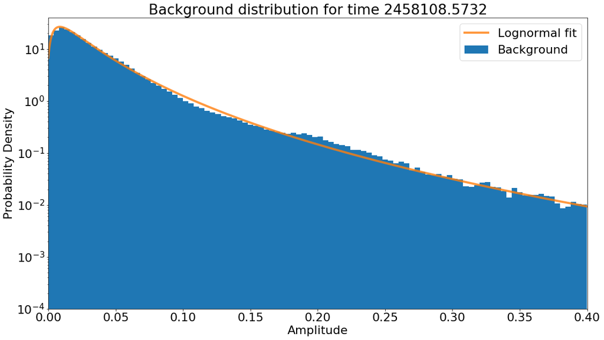

```python
hist_data_2 = plot_histogram(hd.times[2], np.arange(100, 800))
sigma_2, mean_2, scale_2 = plot_lognormal_fit(hist_data_2)
```

```
Lognormal: mu: -0.0024998924301016428, sigma: 0.9020725356465114, s: 0.02502116601220997
```

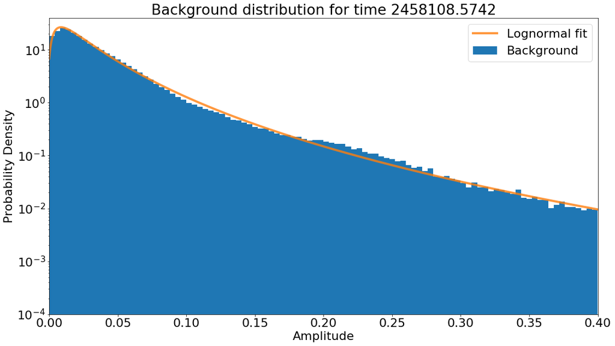

```python
hist_data_10 = plot_histogram(hd.times[10], np.arange(100, 800))
sigma_10, mean_10, scale_10 = plot_lognormal_fit(hist_data_10)
```

```
Lognormal: mu: -0.002347159156485866, sigma: 0.9160047875642501, s: 0.024581662788044877
```

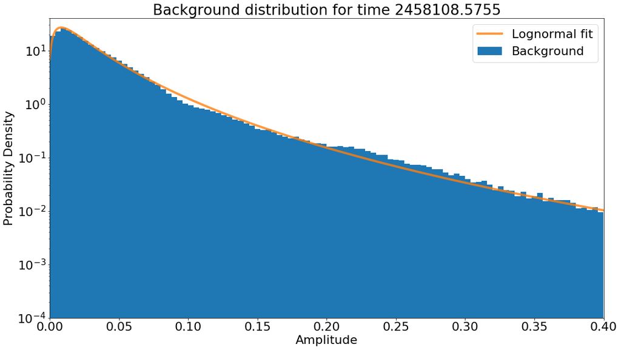

```python
hist_data_20 = plot_histogram(hd.times[20], np.arange(100, 800))
sigma_20, mean_20, scale_20 = plot_lognormal_fit(hist_data_20)
```

```
Lognormal: mu: -0.002180863899106523, sigma: 0.9339889668447542, s: 0.024263765220786455
```

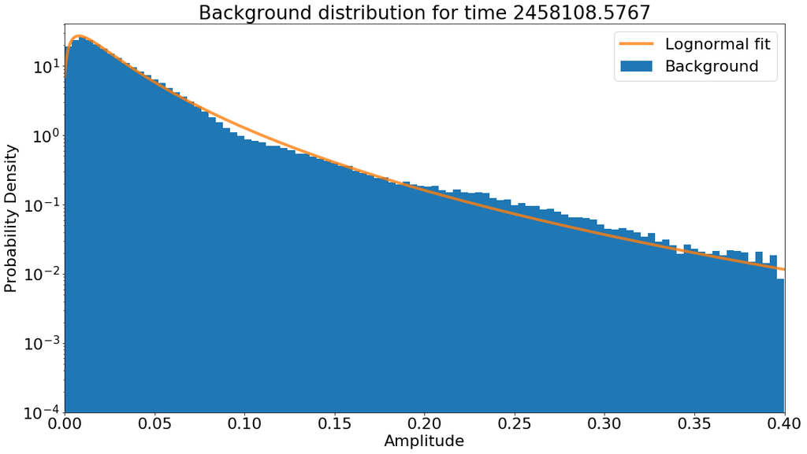

```python
hist_data_30 = plot_histogram(hd.times[30], np.arange(100, 800))
sigma_30, mean_30, scale_30 = plot_lognormal_fit(hist_data_30)
```

The fit parameters for the PDF of the background distribution for the whole telescope array do appear to change very slightly over time. Let's plot the variation of each fit parameter above to see if this change is significant.

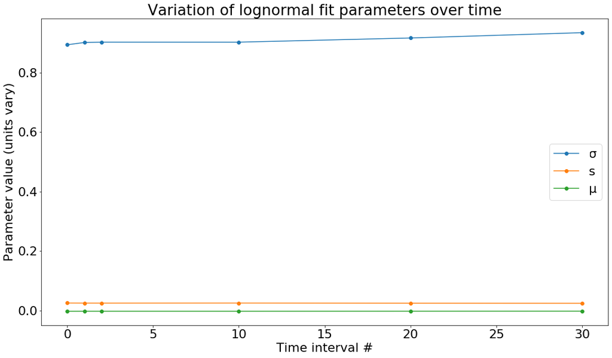

```python
times = [0, 1, 2, 10, 20, 30]
sigmas = [sigma, sigma_1, sigma_2, sigma_10, sigma_20, sigma_30]
means = [mean, mean_1, mean_2, mean_10, mean_20, mean_30]
scales = [scale, scale_1, scale_2, scale_10, scale_20, scale_30]

plt.title('Variation of lognormal fit parameters over time')
plt.xlabel('Time interval #')
plt.ylabel('Parameter value (units vary)')
plt.plot(times, sigmas, 'o-')
plt.plot(times, scales, 'o-')
plt.plot(times, means, 'o-')
plt.legend(['σ', 's', 'μ']);
```

The parameters do not appear to change much for different intervals of time, so it's probably safe to say the background is not dependent on time.

What if we want to examine another polarization, say, XY? Let's make some plots just like before:

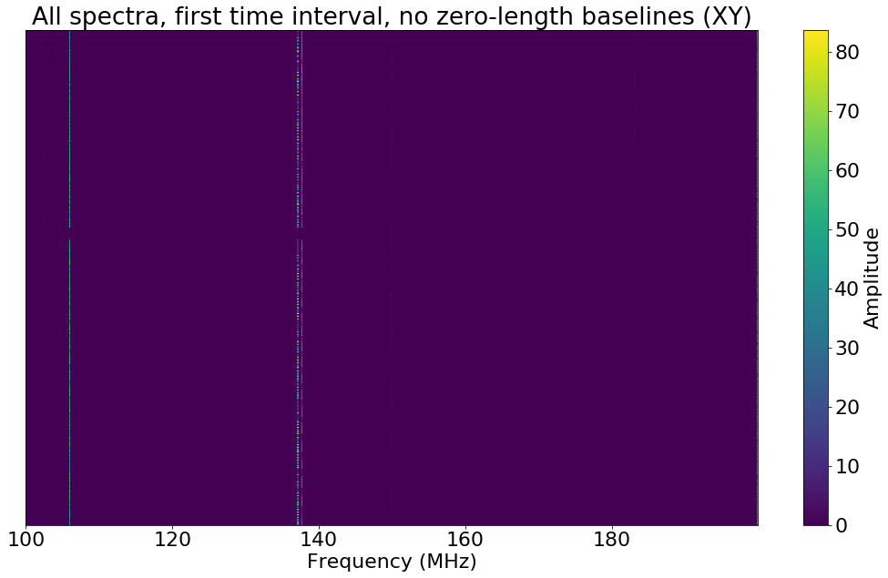

```python
data, times, freqs_mhz = get_spectrogram(hd, hd.times[0:1], np.arange(0, 1024), 'XY', filter_dupes=True)
plt.title('All spectra, first time interval, no zero-length baselines (XY)')
plot_spectrogram(freqs_mhz, times, data, colorbar=True)
```

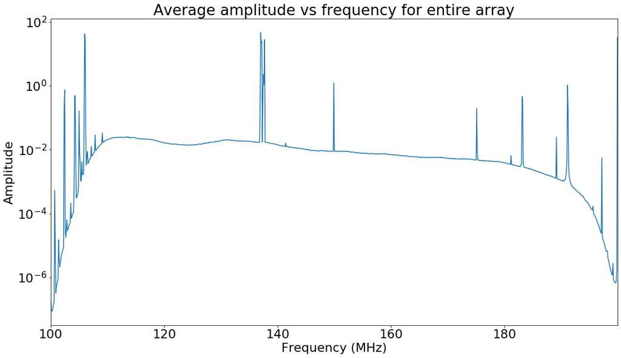

```python
plot_avg_amplitudes(freqs_mhz, times, data)
plt.title('Average amplitude vs frequency for entire array')
plt.yscale('log')
```

Notice the background here is a bit lower on average than the XX-polarized light.

```
Lognormal: mu: -0.000780239249019701, sigma: 0.8452870240932331, s: 0.009561197189129185
```

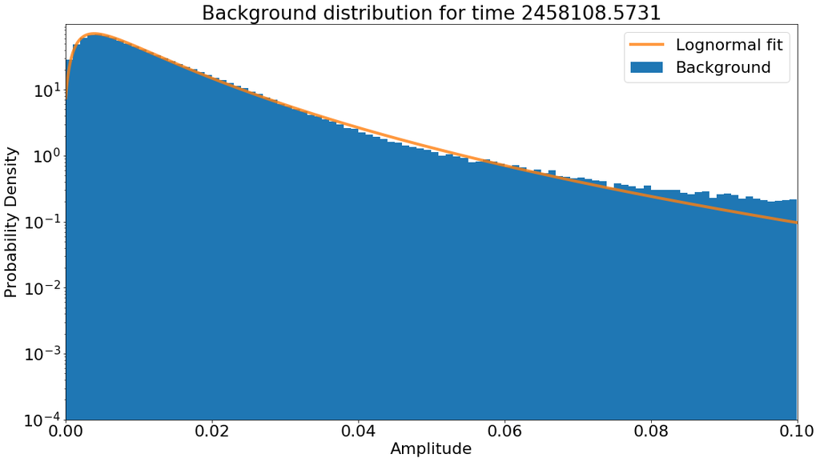

```python
hist_data = plot_histogram(hd.times[1], np.arange(100, 800), 0.1, 'XY')
sigma, mean, scale = plot_lognormal_fit(hist_data, 0.1)
```